# Introduction to ggplot2

### Geometric objects

The geoms are geometric objects (points, lines, and so on) that is placed on a graph. In ggplot2, the functions for geoms start with `geom_`. For example, `geom_point()` is used to add points in the graph, and `geom_line()` is used to add lines. For this example, we will use `geom_points()` to create a scatterplot.

To add the selected geoms to the graph, we chain the `ggplot()` function written before with the `geom_` function with a `+` sign.

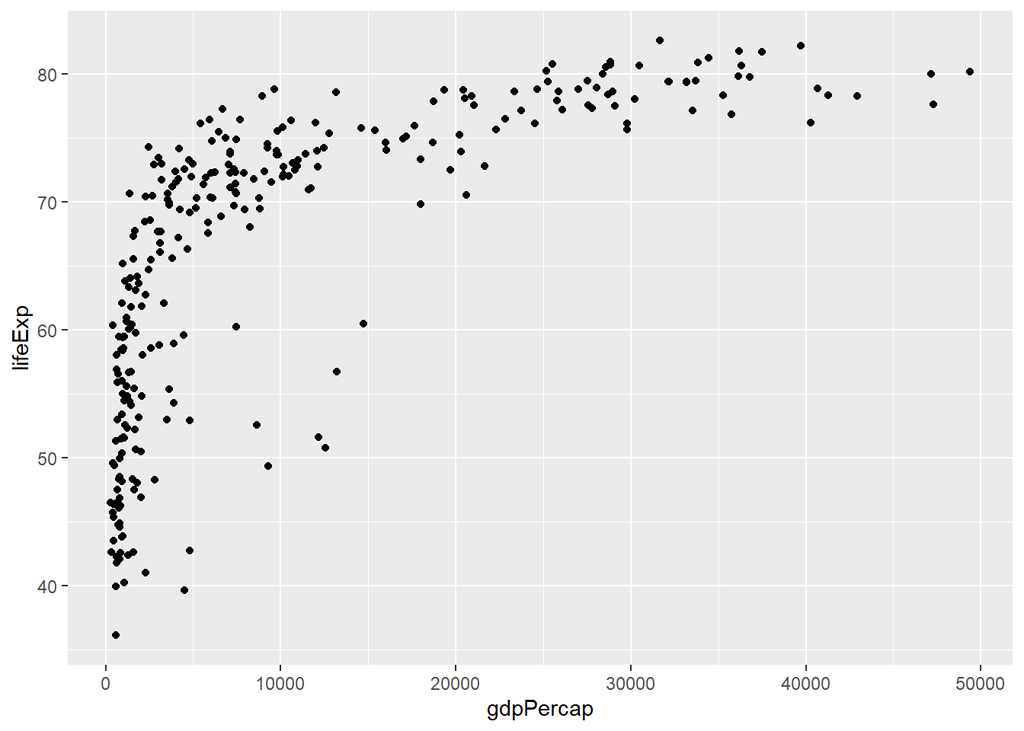

```r
ggplot(data = gm_df,                                # Data is gm_df
       mapping = aes(x=gdpPercap, y=lifeExp)) +     # Specify x and y
  geom_point()                                      # Add points to the plot
```

As you can see, now we have points in the plot and have produced a scatterplot.

There are options you can use when calling the `geom_` function. For `geom_point()`, some of the options are `color`, `size` and `shape`. You can check these by running `help(geom_point)` or `?geom_point`. Note that for the `shape` argument, you can use characters such as `"o"` or numbers, as shown in previous topic for scatterplot.

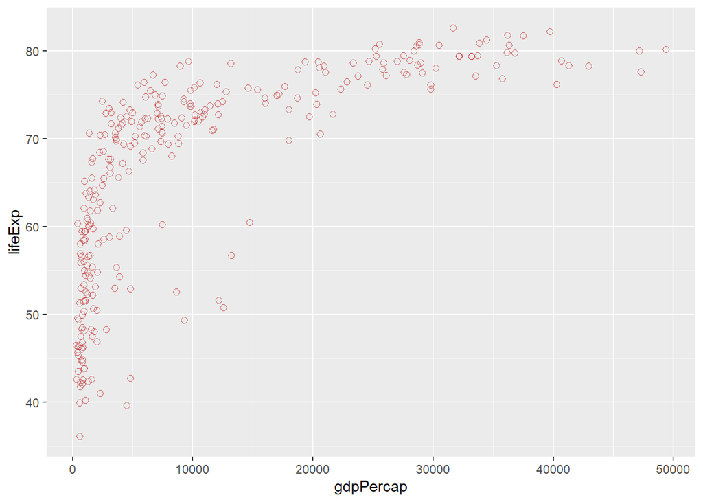

```r
ggplot(data = gm_df,                                # Data is gm_df
       mapping = aes(x=gdpPercap, y=lifeExp)) +     # Specify x and y
  geom_point(color="indianred3", size=2, shape=1)   # Add points to the plot
```

If you want to add another geom object on the plot, you just have to chain another `geom_` function with a `+` sign.

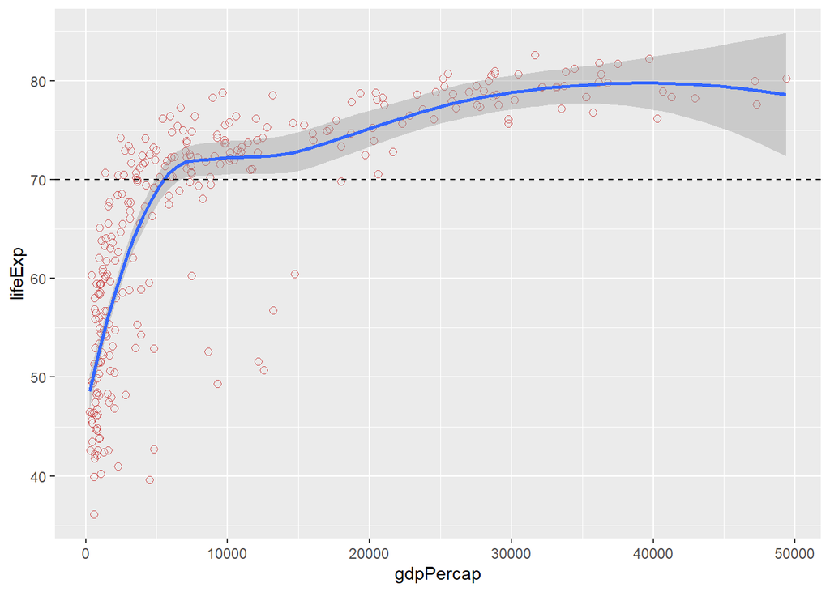

```r
ggplot(data = gm_df,                                 # Data is gm_df
       mapping = aes(x=gdpPercap, y=lifeExp)) +      # Specify x and y
  geom_point(color="indianred3", size=2, shape=1) +  # Add points to the plot
  geom_smooth() +                                    # Add smooth line
  geom_hline(yintercept = 70, linetype = 2)          # Add horizontal line
```

### Mapping of different color, shape and size

The mapping argument in `ggplot()` can also be used modify the color, shape, size, and other characteristics for the data. To do that, you need to add extra arguments in the `aes()` function. In the code below, we change the color based on the country’s continent, and the size of the points by the country’s population.

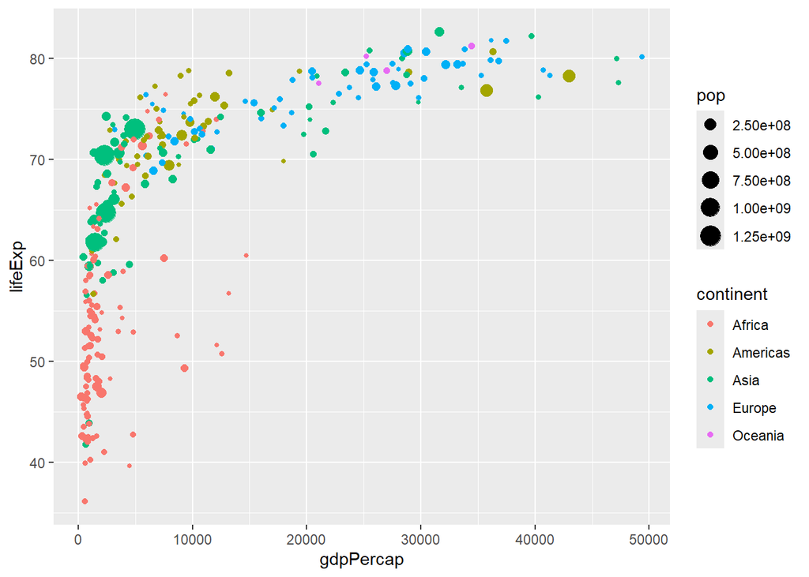

```r
ggplot(data = gm_df,                          # Data is gm_df
       mapping = aes(x=gdpPercap, y=lifeExp,  # Specify x and y
                     color=continent,         # Color of data by continent
                     size=pop)) +             # Make the size depends on pop
  geom_point()                                # Add points in plot
```

Note that the `color` argument in the `aes()` function is very useful if you want to show different groups of data in the plot.

You can also use `shape` argument in the `aes()` function to group the data.

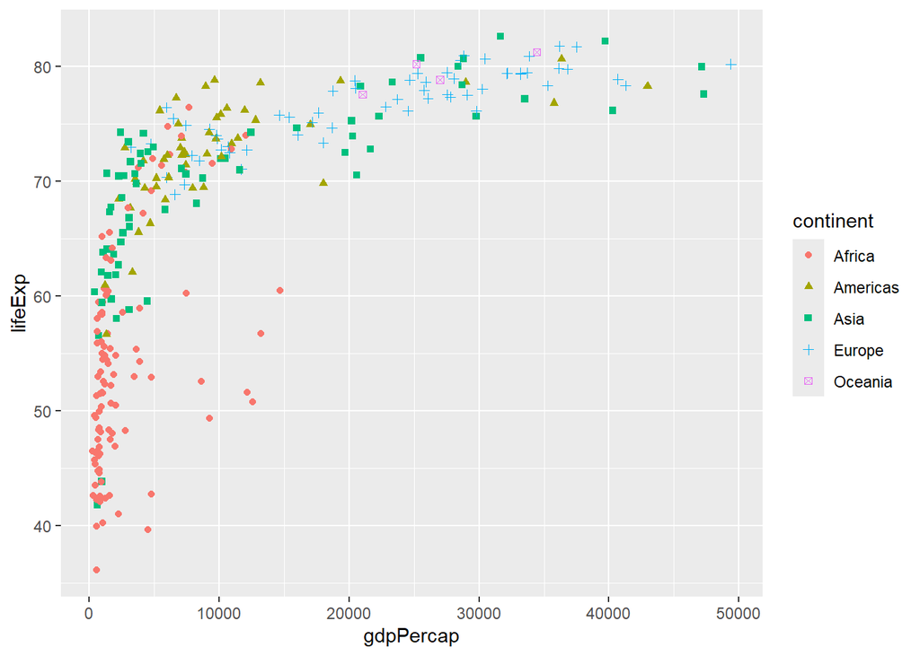

```r
ggplot(data = gm_df,                          # Data is gm_df
       mapping = aes(x=gdpPercap, y=lifeExp,  # Specify x and y
                     shape=continent,         # Shape of data by continent
                     color=continent)) +      # Color of data point by continent
  geom_point()                                # Add points in plot
```

When the mapping in `aes()` is included in the `ggplot()` function, it becomes the global mapping for the plot. However, we can also use the mapping inside of the `geom_` function to have individual mapping. This can be useful if we want to further customize the shape, color, and so on.

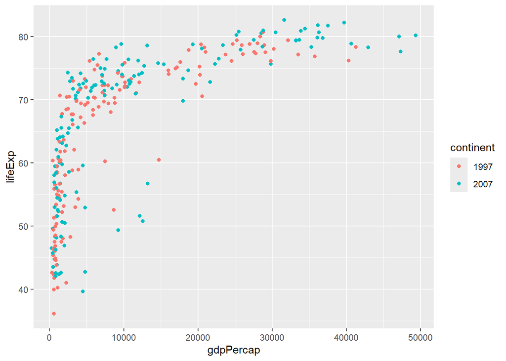

```r
ggplot(data = gm_df,                                # Data is gm_df
       mapping = aes(x=gdpPercap, y=lifeExp,        # Specify x and y
                     color=continent)) +            # Color of data point by continent
  geom_point(mapping = aes(color=as.factor(year)))  # Add points in plot in indianred3 color
```

Notice that the individual mapping overlaps with the global mapping regarding the color of data points. In this case, the individual mapping takes priority and is used. However, the title of the legend for the color follows the global mapping.

### Scales

For each aesthetic, the scales are used to control how variables are used in the plot. We can modify the scale by adding scale functions of the form `scale_` and chain it using the `+` sign. For example, for the scatterplot of life expectation vs GDP per capita before, we might want to use a log scale for the GDP per capita, and use `scale_x_log10()` in our code.

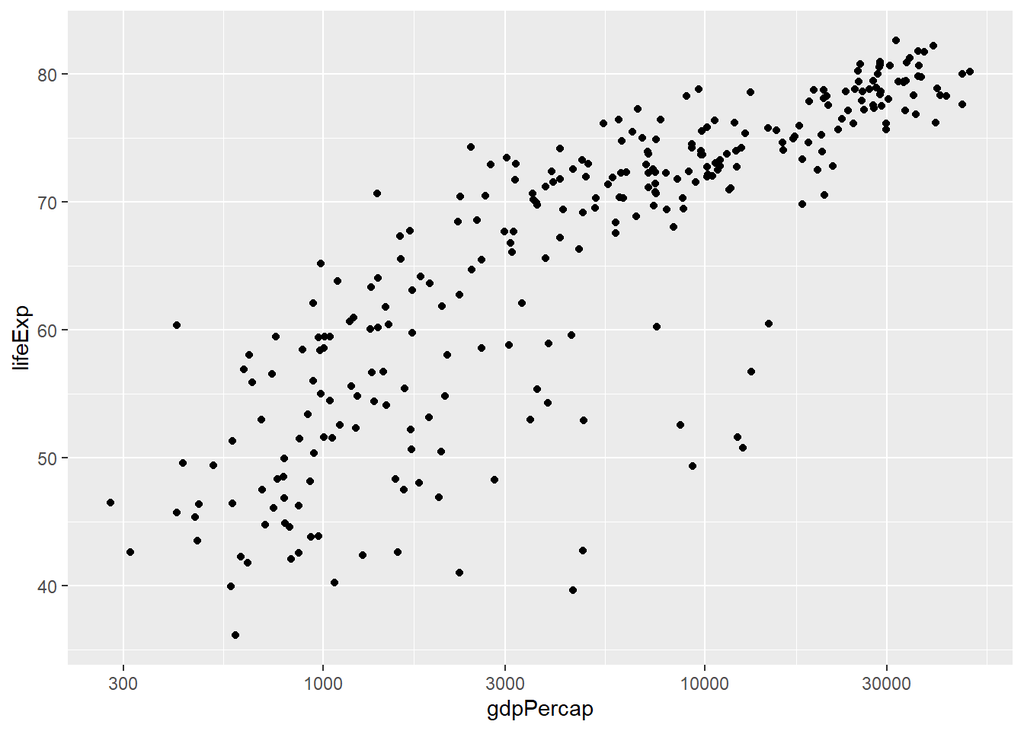

```r
ggplot(data = gm_df,
       mapping = aes(x=gdpPercap, y=lifeExp)) +
  geom_point() +

  # Scale the x-axis by log10
  scale_x_log10()
```

Notice the change in the x-axis in the figure above. If we also want to include currency in the x-axis label, we can add another argument to the `scale_x_log10()` function.

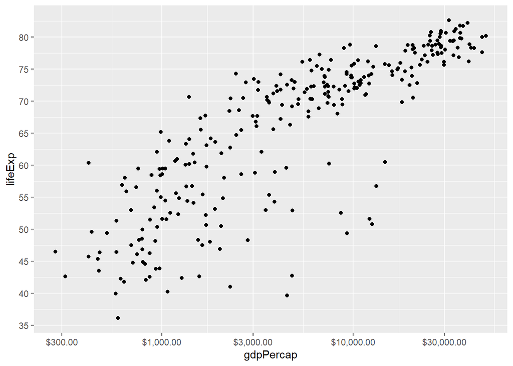

```r
# Load scales package for label_currency() function
# Otherwise, you need to use 'scales::label_currency()'
library(scales)

ggplot(data = gm_df,
       mapping = aes(x=gdpPercap, y=lifeExp)) +
  geom_point() +

  # Change the x axis to log10 scale with currency label
  scale_x_log10(labels = label_currency()) +

  # or (same result)
  # scale_x_continuous(labels = scales::label_currency(), trans="log10") +

  # Change the tick marks on the y-axis
  scale_y_continuous(breaks = seq(30,100,by=5))
```

### Facets

Facets are used split the data into groups or subsets and draw graph for each of them separately. To create facets, we can add the `facet_` function into the chain. There are two `facet_` functions in ggplot2. First is `facet_wrap` which uses the formula object as the argument, and groups the data based on the specified formula.

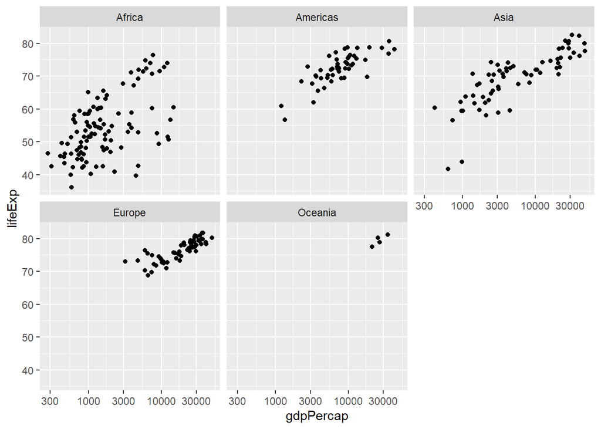

```r
ggplot(data = gm_df,
       mapping = aes(x=gdpPercap, y=lifeExp)) +
  geom_point() +
  scale_x_log10() +

  facet_wrap(~continent)
```

Second is the `facet_grid()` function, that creates a grid-like output with specified variables for rows and columns.

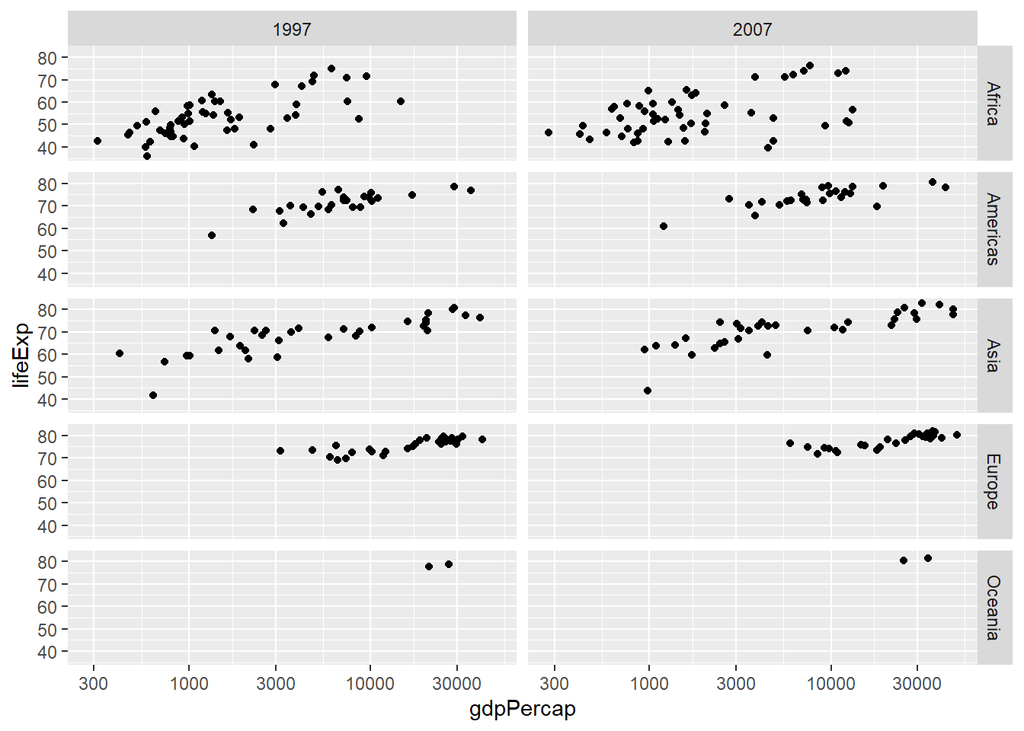

```r
ggplot(data = gm_df,
       mapping = aes(x=gdpPercap, y=lifeExp)) +
  geom_point() +
  scale_x_log10() +

  facet_grid(rows=vars(continent), cols=vars(year))
```

### Title, subtitle, and axis labels

To add title, subtitle and custom labels for the x and y axes, we can add the `labs()` function to the chain. Here are some of the main arguments for the `labs()` function.

- `title`: Add title to the plot.
- `subtitle`: Add subtitle to the plot.
- `x`, `y`: The x and y axis labels.
- `caption`: Add caption to the plot
- `color`, `shape`, `size`: The title for the legends for color, shape and size (if used).

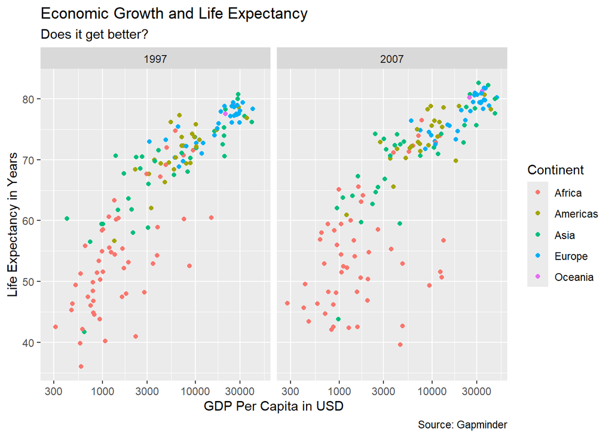

```r
ggplot(data = gm_df,
       mapping = aes(x=gdpPercap, y=lifeExp, color = continent)) +
  geom_point() +
  scale_x_log10() +
  facet_wrap(~year) +

  labs(title = "Economic Growth and Life Expectancy", # Title of the plot
       subtitle = "Does it get better?",              # Subtitle
       x = "GDP Per Capita in USD",                   # x-axis label
       y = "Life Expectancy in Years",                # y-axis label
       color = "Continent",                           # Legend for colors
       caption = "Source: Gapminder")                 # Caption
```

### Themes

Another useful feature of ggplot2 are the themes. Themes control the colors, fonts, and other visual properties of a plot. To use the theme functions, we simply add another `theme_` function to the chain. The ggplot2 comes with eight different themes: `theme_grey()`, `theme_bw()`, `theme_linedraw()`, `theme_light()`, `theme_dark()`, `theme_minimal()`, `theme_classic()`, `theme_void()` .

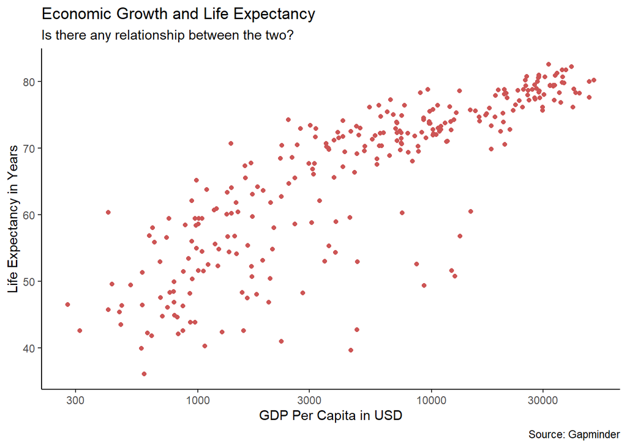

```r
ggplot(data = gm_df,
       mapping = aes(x=gdpPercap, y=lifeExp)) +
  geom_point(color="indianred3") +
  scale_x_log10() +
  labs(title = "Economic Growth and Life Expectancy",
       subtitle = "Is there any relationship between the two?",
       x = "GDP Per Capita in USD",
       y = "Life Expectancy in Years",
       caption = "Source: Gapminder") +
  theme_classic()
```

Alternatively, you can write your own theme using the `theme()` function.

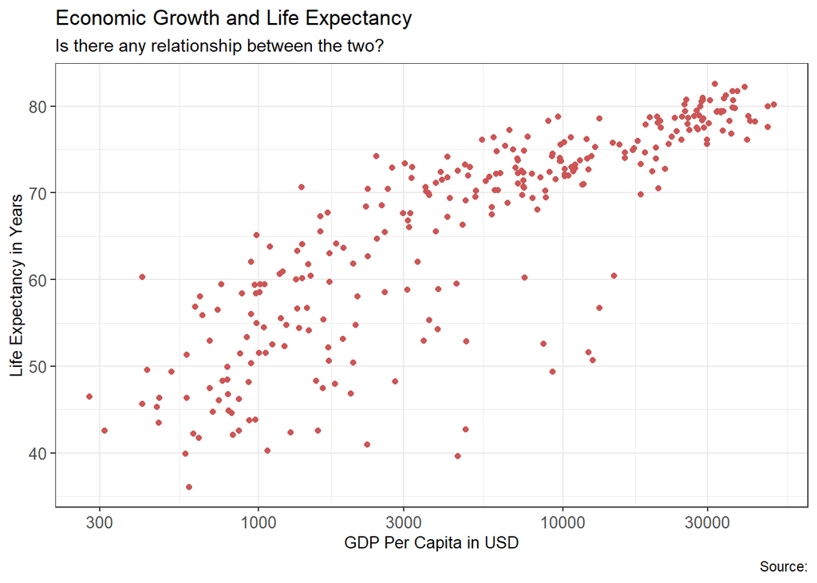

```r
mytheme <- theme_bw() +                   # We start with bw theme
  theme(
    axis.title = element_text(size=10),   # And overrite the paramaters
    axis.text = element_text(size=10),
    legend.title = element_text(size=10),
    legend.text = element_text(size=10)
    )

ggplot(data = gm_df,
       mapping = aes(x=gdpPercap, y=lifeExp)) +
  geom_point(color="indianred3") +
  scale_x_log10() +
  labs(title = "Economic Growth and Life Expectancy",
       subtitle = "Is there any relationship between the two?",
       x = "GDP Per Capita in USD",
       y = "Life Expectancy in Years",
       caption = "Source:") +
  mytheme
```

## Conclusion

This topic discusses on the usage of ggplot2 to produce visuals, figures, and plots, as well as its properties. In the next following topics, we will show more examples on producing visuals using ggplot2, starting with visuals for displaying distribution of data.